# 泰坦尼克数据分析

## 基本流程 概括

1. 提出问题
2. 环境配置
3. 加载泰坦尼克号生存数据
4. 展示基本数据指标
5. 字段分析
6. 处理字段缺失值
7. 选择多个自变量并单独展示其与因变量（是否幸存）的关系
8. 多个自变量两两组合并展示其与因变量的关系
9. 多个自变量三三组合并展示其与因变量的关系
10. 给出初步结论
11. 验证结论的准确性
12. 数据分析总结

## 问题

乘客信息的哪些特征的哪些值会导致乘客的获救概率最大？

## 环境配置

```python
import sys,os
import numpy as np
import pandas as pd
import matplotlib.pyplot as plt

%matplotlib inline
```

## 加载数据

```python
titanic = pd.read_csv('data_set/titanicdatabank/titanic-data.csv')
```

## 展示数据基本指标

```python
titanic.head(10)
```

|  | PassengerId | Survived | Pclass | Name | Sex | Age | SibSp | Parch | Ticket | Fare | Cabin | Embarked |
| --- | --- | --- | --- | --- | --- | --- | --- | --- | --- | --- | --- | --- |
| 0 | 1 | 0 | 3 | Braund, Mr. Owen Harris | male | 22.0 | 1 | 0 | A/5 21171 | 7.2500 | NaN | S |
| 1 | 2 | 1 | 1 | Cumings, Mrs. John Bradley (Florence Briggs Th... | female | 38.0 | 1 | 0 | PC 17599 | 71.2833 | C85 | C |
| 2 | 3 | 1 | 3 | Heikkinen, Miss. Laina | female | 26.0 | 0 | 0 | STON/O2. 3101282 | 7.9250 | NaN | S |
| 3 | 4 | 1 | 1 | Futrelle, Mrs. Jacques Heath (Lily May Peel) | female | 35.0 | 1 | 0 | 113803 | 53.1000 | C123 | S |
| 4 | 5 | 0 | 3 | Allen, Mr. William Henry | male | 35.0 | 0 | 0 | 373450 | 8.0500 | NaN | S |
| 5 | 6 | 0 | 3 | Moran, Mr. James | male | NaN | 0 | 0 | 330877 | 8.4583 | NaN | Q |
| 6 | 7 | 0 | 1 | McCarthy, Mr. Timothy J | male | 54.0 | 0 | 0 | 17463 | 51.8625 | E46 | S |
| 7 | 8 | 0 | 3 | Palsson, Master. Gosta Leonard | male | 2.0 | 3 | 1 | 349909 | 21.0750 | NaN | S |
| 8 | 9 | 1 | 3 | Johnson, Mrs. Oscar W (Elisabeth Vilhelmina Berg) | female | 27.0 | 0 | 2 | 347742 | 11.1333 | NaN | S |
| 9 | 10 | 1 | 2 | Nasser, Mrs. Nicholas (Adele Achem) | female | 14.0 | 1 | 0 | 237736 | 30.0708 | NaN | C |

```python
titanic.info()
```

```
<class 'pandas.core.frame.DataFrame'>
RangeIndex: 891 entries, 0 to 890
Data columns (total 12 columns):
PassengerId    891 non-null int64
Survived       891 non-null int64
Pclass         891 non-null int64
Name           891 non-null object
Sex            891 non-null object
Age            714 non-null float64
SibSp          891 non-null int64
Parch          891 non-null int64
Ticket         891 non-null object
Fare           891 non-null float64
Cabin          204 non-null object
Embarked       889 non-null object
dtypes: float64(2), int64(5), object(5)
memory usage: 83.6+ KB
```

```python
titanic.describe()
```

|  | PassengerId | Survived | Pclass | Age | SibSp | Parch | Fare |
| --- | --- | --- | --- | --- | --- | --- | --- |
| count | 891.000000 | 891.000000 | 891.000000 | 714.000000 | 891.000000 | 891.000000 | 891.000000 |
| mean | 446.000000 | 0.383838 | 2.308642 | 29.699118 | 0.523008 | 0.381594 | 32.204208 |
| std | 257.353842 | 0.486592 | 0.836071 | 14.526497 | 1.102743 | 0.806057 | 49.693429 |
| min | 1.000000 | 0.000000 | 1.000000 | 0.420000 | 0.000000 | 0.000000 | 0.000000 |
| 25% | 223.500000 | 0.000000 | 2.000000 | 20.125000 | 0.000000 | 0.000000 | 7.910400 |
| 50% | 446.000000 | 0.000000 | 3.000000 | 28.000000 | 0.000000 | 0.000000 | 14.454200 |
| 75% | 668.500000 | 1.000000 | 3.000000 | 38.000000 | 1.000000 | 0.000000 | 31.000000 |
| max | 891.000000 | 1.000000 | 3.000000 | 80.000000 | 8.000000 | 6.000000 | 512.329200 |

## 字段分析

- PassengerId
  - 乘客唯一id
  - 递增的，应该没有业务意义；
- Survived
  - 乘客是否幸存
  - 这个是因变量，评估数据分析机器学习的指标；
- Pclass
  - 船票等级1：头等舱,2：商务舱,3：经济舱
  - 可以分析，也许更高级的船舱有更好的安全设施或者更方便逃生，Fare字段跟Pclass可以互相验证，可以和Sex，Age组成年龄-性别-阶层联合特征；
  - link -- Sex，Age
- Name
  - 乘客姓名
  - 自身无分析价值，但是可以用于辅助age，sex字段的补全工作，以及社会地位的估计（例如master）
  - link -- age,sex,social position(new)
- Sex
  - 性别
  - 女士优先，很重要的特征，也许配合年龄，可以实现小女孩，女性青年，大龄女性，大龄男性，男性青年，小男孩的细分分析
  - link -- age,people_part(小女孩，女性青年，大龄女性，大龄男性，男性青年，小男孩)
- Age
  - 年龄
  - 小孩和老人优先，很重要的特征，配合性别进行更细致的分析
  - link -- sex
- SibSp
  - 兄弟姐妹丈夫妻子人数
  - 也许兄弟姐妹更多的人获救的可能性越大
- Parch
  - 父母孩子人数
  - 也许有父母孩子的人更倾向于救父母和孩子先，自己获救的几率会下降
- Ticket
  - 船票
  - 不知道咋整
- Fare
  - 船票价格
  - 可以根据pclass进行进一步的价钱细分
- Cabin
  - 船舱号码
  - 这个由于没有其他数据，不知道具体位置，但是可以通过船票的值来猜测是否跟在船上的位置有关；
  - 有缺失的问题看是否可以通过pclass和fare来补全
  - link -- pclass,fare
- Embarked
  - 登陆港口
  - 也许各个港口代表的人群不一样，也许各个港口的人更倾向于救助自己港口的人，老乡之类的关心，或者同一个港口经济情况更接近；

## 处理缺失值

#### Age

```python
# Age字段缺失值处理，通过Name，SibSp，Parch来填充该缺失值字段
# Name：Mr，Mrs，Miss，Master
# SibSp：int
# Parch：int
sibsp_max = titanic.SibSp.max()+1
parch_max = titanic.Parch.max()+1
mr_sibsp_parch = [[0 for j in range(sibsp_max)] for i in range(parch_max)]
mrs_sibsp_parch = [[0 for j in range(sibsp_max)] for i in range(parch_max)]
miss_sibsp_parch = [[0 for j in range(sibsp_max)] for i in range(parch_max)]
master_sibsp_parch = [[0 for j in range(sibsp_max)] for i in range(parch_max)]
titanic_has_age = titanic[pd.notnull(titanic.Age)]
titanic_has_age.Mr = titanic_has_age.Name.apply(lambda name:1 if 'Mr.' in name else 0)
titanic_has_age.Mrs = titanic_has_age.Name.apply(lambda name:1 if 'Mrs.' in name else 0)
titanic_has_age.Miss = titanic_has_age.Name.apply(lambda name:1 if 'Miss.' in name else 0)
titanic_has_age.Master = titanic_has_age.Name.apply(lambda name:1 if 'Master.' in name else 0)
age_mean = titanic_has_age.Age.mean()
for i in range(parch_max):
    for j in range(sibsp_max):
        age_ij = ((titanic_has_age.Age[titanic_has_age.SibSp==j])[titanic_has_age.Parch==i])
        mr_age_ij = age_ij[titanic_has_age.Mr==1]
        mr_sibsp_parch[i][j] = mr_age_ij.mean() if len(mr_age_ij) > 0 else age_mean
        mrs_age_ij = age_ij[titanic_has_age.Mrs==1]
        mrs_sibsp_parch[i][j] = mrs_age_ij.mean() if len(mrs_age_ij) > 0 else age_mean
        miss_age_ij = age_ij[titanic_has_age.Miss==1]
        miss_sibsp_parch[i][j] = miss_age_ij.mean() if len(miss_age_ij) > 0 else age_mean
        master_age_ij = age_ij[titanic_has_age.Master==1]
        master_sibsp_parch[i][j] = master_age_ij.mean() if len(master_age_ij) > 0 else age_mean

titanic_not_age = titanic[pd.isnull(titanic.Age)]
ages = [0 for i in range(len(titanic_not_age))]
idx=0
for i in titanic_not_age.index:
    sibsp = titanic_not_age.loc[i].SibSp
    parch = titanic_not_age.loc[i].Parch
    name = titanic_not_age.loc[i].Name
    if 'Mr.' in name:
        ages[idx] = mr_sibsp_parch[parch][sibsp]
    elif 'Mrs.' in name:
        ages[idx] = mrs_sibsp_parch[parch][sibsp]
    elif 'Miss.' in name:
        ages[idx] = miss_sibsp_parch[parch][sibsp]
    elif 'Master.' in name:
        ages[idx] = master_sibsp_parch[parch][sibsp]
    else:
        ages[idx] = age_mean
    idx+=1
titanic.loc[ (titanic.Age.isnull()), 'Age' ] = ages
```

## 单个变量

#### Pclass

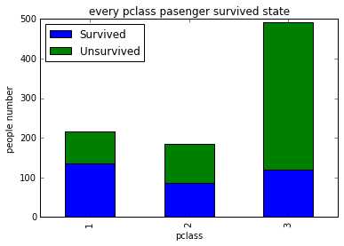

```python
fig = plt.figure()
fig.set(alpha=0.2)

Survived_0 = titanic.Pclass[titanic.Survived == 0].value_counts()
Survived_1 = titanic.Pclass[titanic.Survived == 1].value_counts()
df=pd.DataFrame({u'Survived':Survived_1, u'Unsurvived':Survived_0})
df.plot(kind='bar', stacked=True)
plt.title(u"every pclass pasenger survived state")
plt.xlabel(u"pclass")
plt.ylabel(u"people number")
```

图示结果：能够看到Pclass为1时，乘客的幸存几率更大，而3则最低，且差距非常明显，证明Pclass是一个重要的特征；

#### Fare

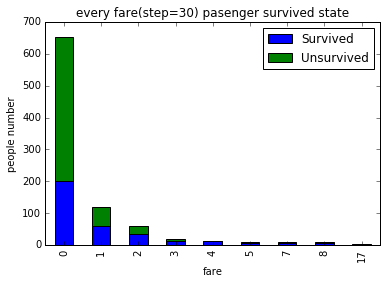

```python
fig = plt.figure()
fig.set(alpha=0.2)

titanic.FareStep = titanic.Fare.apply(lambda fare:int(fare / 30)) # step化Fare字段

Survived_0 = titanic.FareStep[titanic.Survived == 0].value_counts()
Survived_1 = titanic.FareStep[titanic.Survived == 1].value_counts()
df=pd.DataFrame({u'Survived':Survived_1, u'Unsurvived':Survived_0})
df.plot(kind='bar', stacked=True)
plt.title(u"every fare(step=30) pasenger survived state")
plt.xlabel(u"fare")
plt.ylabel(u"people number")
```

图示结果：能够看到对于Fare字段，值越大，幸存率越高，且差距非常明显，证明Fare是一个重要的特征，同样的由于Pclass和Fare有很强的相关性，因此二者目前的结果一致也互相增加了可信度；

#### Sex

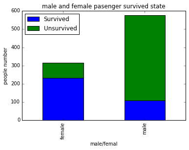

```python
fig = plt.figure()
fig.set(alpha=0.2)

Survived_0 = titanic.Sex[titanic.Survived == 0].value_counts()
Survived_1 = titanic.Sex[titanic.Survived == 1].value_counts()
df=pd.DataFrame({u'Survived':Survived_1, u'Unsurvived':Survived_0})
df.plot(kind='bar', stacked=True)
plt.title(u"male and female pasenger survived state")
plt.xlabel(u"male/femal")
plt.ylabel(u"people number")
```

图示结果：能够看到Sex为female时，乘客的幸存几率更大，且差距非常明显，证明Sex是一个重要的特征；

#### Age

```
(0, 20)
```

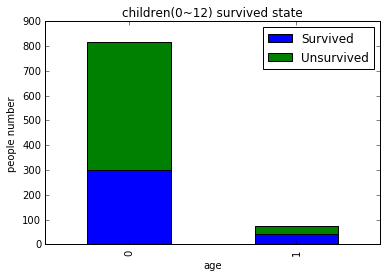

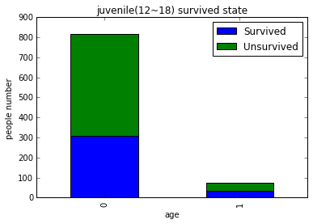

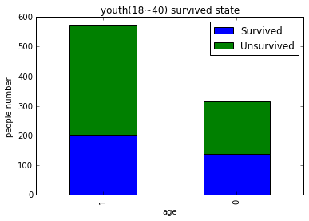

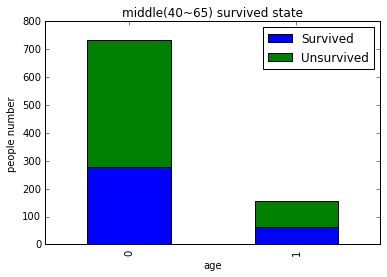

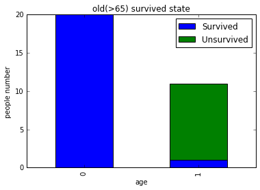

```python
fig = plt.figure()
fig.set(alpha=0.2)

titanic.Children = titanic.Age.apply(lambda age:1 if age < 12 else 0) # 儿童：12以下
titanic.Juvenile = titanic.Age.apply(lambda age:1 if 12 <= age <= 18 else 0) # 少年：12~18岁
titanic.Youth = titanic.Age.apply(lambda age:1 if 19 <= age < 40 else 0) # 青年：19~40岁
titanic.Middle = titanic.Age.apply(lambda age:1 if 40 <= age < 65 else 0) # 中年：40~65岁
titanic.Old = titanic.Age.apply(lambda age:1 if age >= 65 else 0) # 中年：65以上

Survived_0 = titanic.Children[titanic.Survived == 0].value_counts()
Survived_1 = titanic.Children[titanic.Survived == 1].value_counts()
df=pd.DataFrame({u'Survived':Survived_1, u'Unsurvived':Survived_0})
df.plot(kind='bar', stacked=True)
plt.title(u"children(0~12) survived state")
plt.xlabel(u"age")
plt.ylabel(u"people number")

Survived_0 = titanic.Juvenile[titanic.Survived == 0].value_counts()
Survived_1 = titanic.Juvenile[titanic.Survived == 1].value_counts()
df=pd.DataFrame({u'Survived':Survived_1, u'Unsurvived':Survived_0})
df.plot(kind='bar', stacked=True)
plt.title(u"juvenile(12~18) survived state")
plt.xlabel(u"age")
plt.ylabel(u"people number")

Survived_0 = titanic.Youth[titanic.Survived == 0].value_counts()
Survived_1 = titanic.Youth[titanic.Survived == 1].value_counts()
df=pd.DataFrame({u'Survived':Survived_1, u'Unsurvived':Survived_0})
df.plot(kind='bar', stacked=True)
plt.title(u"youth(18~40) survived state")
plt.xlabel(u"age")
plt.ylabel(u"people number")

Survived_0 = titanic.Middle[titanic.Survived == 0].value_counts()
Survived_1 = titanic.Middle[titanic.Survived == 1].value_counts()
df=pd.DataFrame({u'Survived':Survived_1, u'Unsurvived':Survived_0})
df.plot(kind='bar', stacked=True)
plt.title(u"middle(40~65) survived state")
plt.xlabel(u"age")
plt.ylabel(u"people number")

Survived_0 = titanic.Old[titanic.Survived == 0].value_counts()
Survived_1 = titanic.Old[titanic.Survived == 1].value_counts()
df=pd.DataFrame({u'Survived':Survived_1, u'Unsurvived':Survived_0})
df.plot(kind='bar', stacked=True)
plt.title(u"old(>65) survived state")
plt.xlabel(u"age")
plt.ylabel(u"people number")
plt.ylim(0,20)
```

图示结果：能够看到Children获救比例是最大的，其次是Juvenile，而youth和middle则明显是要小于50%的，而old的获救比例也很低，这个有可能是因为老年人在遇到意外情况时由于身体健康等各方面原因导致最后幸存的可能性不大；

#### SibSp

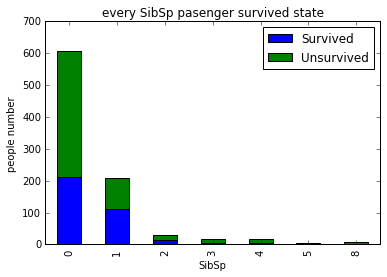

```python
fig = plt.figure()
fig.set(alpha=0.2)

Survived_0 = titanic.SibSp[titanic.Survived == 0].value_counts()
Survived_1 = titanic.SibSp[titanic.Survived == 1].value_counts()
df=pd.DataFrame({u'Survived':Survived_1, u'Unsurvived':Survived_0})
df.plot(kind='bar', stacked=True)
plt.title(u"every SibSp pasenger survived state")
plt.xlabel(u"SibSp")
plt.ylabel(u"people number")
```

图示结果：能够看到SibSp为1时，乘客的幸存几率最大，为2时也接近50%，而其他情况下则明显低过前两种情况，5跟8由于样本数量比较少，不太能说明问题，总之这个特征本身看不出太强的规律性，暂时认为不可信；

#### Parch

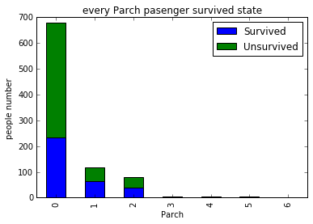

```python
fig = plt.figure()
fig.set(alpha=0.2)

Survived_0 = titanic.Parch[titanic.Survived == 0].value_counts()
Survived_1 = titanic.Parch[titanic.Survived == 1].value_counts()
df=pd.DataFrame({u'Survived':Survived_1, u'Unsurvived':Survived_0})
df.plot(kind='bar', stacked=True)
plt.title(u"every Parch pasenger survived state")
plt.xlabel(u"Parch")
plt.ylabel(u"people number")
```

图示结果：能够看到除去3,4,5,6等四个小样本后，Parch反应出跟SibSp同样情况，1,2的幸存几率是最大的，而0明显要低很多，那么是否可以考虑这两个特征在值为0,1,2的情况下还是可信的呢；

#### Embarked

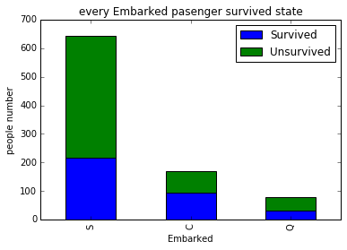

```python
fig = plt.figure()
fig.set(alpha=0.2)

Survived_0 = titanic.Embarked[titanic.Survived == 0].value_counts()
Survived_1 = titanic.Embarked[titanic.Survived == 1].value_counts()
df=pd.DataFrame({u'Survived':Survived_1, u'Unsurvived':Survived_0})
df.plot(kind='bar', stacked=True)
plt.title(u"every Embarked pasenger survived state")
plt.xlabel(u"Embarked")
plt.ylabel(u"people number")
```

图示结果：能够看到Embarked为c时，乘客的幸存几率最大，另外二者都明显低于50%，可能是由于C港口登船的人更多的上层人士（也就是Pclass字段，只有这个字段在逻辑上可能跟某个港口区域有关），证明Embarked是一个重要的特征；

#### 单变量分析结论

1. 性别，船舱等级，船票价格，年龄段，港口有较明显的趋势，可信度很大；
2. 父母子女个数以及兄弟姐妹丈夫妻子个数体现的趋势不是很明确，且有部分数据样本量很小，可信度不大，可作为参考补充；
3. 选择性别，船舱等级（此处不使用船票价格，是因为船舱等级就是一个枚举类型的船票价格，因此使用船舱等级即可），年龄段，港口在双变量中两两组合做进一步分析

## 双变量

首先进行上一步分析后的变量两两组合（船舱等级和船票价格不组成双变量，主要是二者几乎就是一个特征的不同细化）：

1. 性别+船舱等级
2. 性别+年龄段
3. 性别+港口
4. 船舱等级+年龄段
5. 船舱等级+港口

#### Sex+Pclass

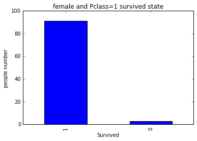

```python
fig = plt.figure()
fig.set(alpha=0.2)

df = titanic.Survived[titanic.Sex=='female'][titanic.Pclass==1].value_counts()
df.plot(kind='bar', stacked=True)
plt.title(u"female and Pclass=1 survived state")
plt.xlabel(u"Survived")
plt.ylabel(u"people number")
```

[figure not shown]

```python
fig = plt.figure()
fig.set(alpha=0.2)

df = titanic.Survived[titanic.Sex=='female'][titanic.Pclass==2].value_counts()
df.plot(kind='bar', stacked=True)
plt.title(u"female and Pclass=1 survived state")
plt.xlabel(u"Survived")
plt.ylabel(u"people number")
```

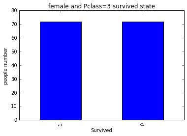

```python
fig = plt.figure()
fig.set(alpha=0.2)

df = titanic.Survived[titanic.Sex=='female'][titanic.Pclass==3].value_counts()
df.plot(kind='bar', stacked=True)
plt.title(u"female and Pclass=3 survived state")
plt.xlabel(u"Survived")
plt.ylabel(u"people number")
```

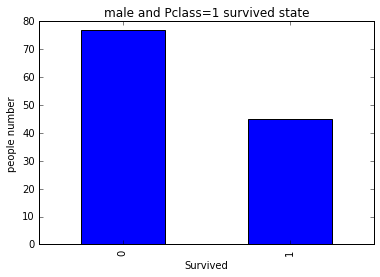

```python
df = titanic.Survived[titanic.Sex == 'male'][titanic.Pclass==1].value_counts()
df.plot(kind='bar', stacked=True)
plt.title(u"male and Pclass=1 survived state")
plt.xlabel(u"Survived")
plt.ylabel(u"people number")
```

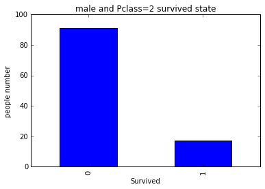

```python
df = titanic.Survived[titanic.Sex == 'male'][titanic.Pclass==2].value_counts()
df.plot(kind='bar', stacked=True)
plt.title(u"male and Pclass=2 survived state")
plt.xlabel(u"Survived")
plt.ylabel(u"people number")
```

```
(0, 310)
```

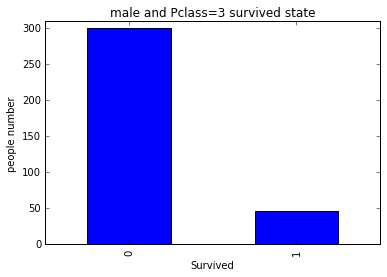

```python
df = titanic.Survived[titanic.Sex == 'male'][titanic.Pclass==3].value_counts()
df.plot(kind='bar', stacked=True)
plt.title(u"male and Pclass=3 survived state")
plt.xlabel(u"Survived")
plt.ylabel(u"people number")
plt.ylim(0,310)
```

图示结果：能够看到非常明显的趋势，在个体性别特征为female且Pclass特征为1时，获救概率极大，而相反的如果个体性别特征为male且pclass为3时，获救概率则远远小于前者，可以说这两个特征的可信度是非常大，也符合基本社会规则；

#### Sex+AgeStep

[figure not shown]

```python
fig = plt.figure()
fig.set(alpha=0.2)

df = titanic.Survived[titanic.Sex=='female'][titanic.Children==1].value_counts()
df.plot(kind='bar', stacked=True)
plt.title(u"female and Pclass=3 survived state")
plt.xlabel(u"Survived")
plt.ylabel(u"people number")
```

[figure not shown]

```python
fig = plt.figure()
fig.set(alpha=0.2)

df = titanic.Survived[titanic.Sex=='female'][titanic.Juvenile==1].value_counts()
df.plot(kind='bar', stacked=True)
plt.title(u"female and Pclass=3 survived state")
plt.xlabel(u"Survived")
plt.ylabel(u"people number")
```

[figure not shown]

```python
fig = plt.figure()
fig.set(alpha=0.2)

df = titanic.Survived[titanic.Sex=='female'][titanic.Youth==1].value_counts()
df.plot(kind='bar', stacked=True)
plt.title(u"female and Pclass=3 survived state")
plt.xlabel(u"Survived")
plt.ylabel(u"people number")
```

[figure not shown]

```python
fig = plt.figure()
fig.set(alpha=0.2)

df = titanic.Survived[titanic.Sex=='female'][titanic.Middle==1].value_counts()
df.plot(kind='bar', stacked=True)
plt.title(u"female and Pclass=3 survived state")
plt.xlabel(u"Survived")
plt.ylabel(u"people number")
```

[figure not shown]

```python
fig = plt.figure()
fig.set(alpha=0.2)

df = titanic.Survived[titanic.Sex=='male'][titanic.Children==1].value_counts()
df.plot(kind='bar', stacked=True)
plt.title(u"male and Pclass=3 survived state")
plt.xlabel(u"Survived")
plt.ylabel(u"people number")
```

[figure not shown]

```python
fig = plt.figure()
fig.set(alpha=0.2)

df = titanic.Survived[titanic.Sex=='male'][titanic.Juvenile==1].value_counts()
df.plot(kind='bar', stacked=True)
plt.title(u"male and Pclass=3 survived state")
plt.xlabel(u"Survived")
plt.ylabel(u"people number")
```

[figure not shown]

```python
fig = plt.figure()
fig.set(alpha=0.2)

df = titanic.Survived[titanic.Sex=='male'][titanic.Youth==1].value_counts()
df.plot(kind='bar', stacked=True)
plt.title(u"male and Pclass=3 survived state")
plt.xlabel(u"Survived")
plt.ylabel(u"people number")
```

[figure not shown]

```python
fig = plt.figure()
fig.set(alpha=0.2)

df = titanic.Survived[titanic.Sex=='male'][titanic.Middle==1].value_counts()
df.plot(kind='bar', stacked=True)
plt.title(u"male and Pclass=3 survived state")
plt.xlabel(u"Survived")
plt.ylabel(u"people number")
```

图示结果：能够看到对于年龄段来说，性别起到的作用更大，但是当年龄段都是儿童也就是小于12岁时，二者的获救几率相差不大，也确实体现了当身份为儿童时，行别不会给予过多的考虑，也就是说不存在小女孩要明显优先于小男孩的情况，也是个重要信息；

#### Sex+Embarked

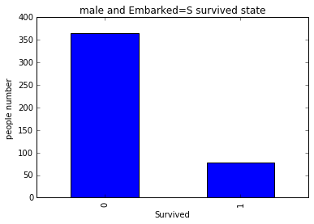

```python
fig = plt.figure()
fig.set(alpha=0.2)

df = titanic.Survived[titanic.Sex=='male'][titanic.Embarked == 'S'].value_counts()
df.plot(kind='bar', stacked=True)
plt.title(u"male and Embarked=S survived state")
plt.xlabel(u"Survived")
plt.ylabel(u"people number")
```

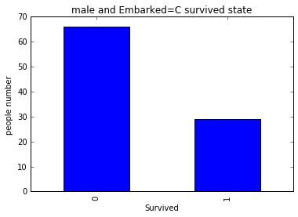

```python
fig = plt.figure()
fig.set(alpha=0.2)

df = titanic.Survived[titanic.Sex=='male'][titanic.Embarked == 'C'].value_counts()
df.plot(kind='bar', stacked=True)
plt.title(u"male and Embarked=C survived state")
plt.xlabel(u"Survived")
plt.ylabel(u"people number")
```

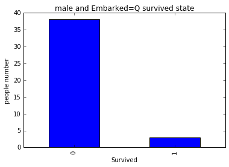

```python
fig = plt.figure()
fig.set(alpha=0.2)

df = titanic.Survived[titanic.Sex=='male'][titanic.Embarked == 'Q'].value_counts()
df.plot(kind='bar', stacked=True)
plt.title(u"male and Embarked=Q survived state")
plt.xlabel(u"Survived")
plt.ylabel(u"people number")
```

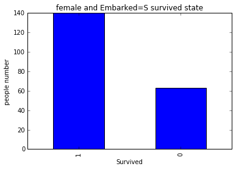

```python
fig = plt.figure()
fig.set(alpha=0.2)

df = titanic.Survived[titanic.Sex=='female'][titanic.Embarked == 'S'].value_counts()
df.plot(kind='bar', stacked=True)
plt.title(u"female and Embarked=S survived state")
plt.xlabel(u"Survived")
plt.ylabel(u"people number")
```

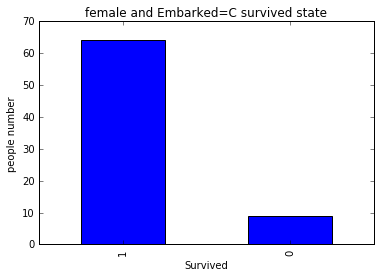

```python
fig = plt.figure()
fig.set(alpha=0.2)

df = titanic.Survived[titanic.Sex=='female'][titanic.Embarked == 'C'].value_counts()
df.plot(kind='bar', stacked=True)
plt.title(u"female and Embarked=C survived state")
plt.xlabel(u"Survived")
plt.ylabel(u"people number")
```

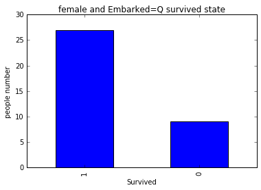

```python
fig = plt.figure()
fig.set(alpha=0.2)

df = titanic.Survived[titanic.Sex=='female'][titanic.Embarked == 'Q'].value_counts()
df.plot(kind='bar', stacked=True)
plt.title(u"female and Embarked=Q survived state")
plt.xlabel(u"Survived")
plt.ylabel(u"people number")
```

#### Pclass+AgeStep

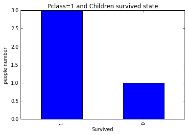

```python
fig = plt.figure()
fig.set(alpha=0.2)

df = titanic.Survived[titanic.Pclass==1][titanic.Children==1].value_counts()
df.plot(kind='bar', stacked=True)
plt.title(u"Pclass=1 and Children survived state")
plt.xlabel(u"Survived")
plt.ylabel(u"people number")
```

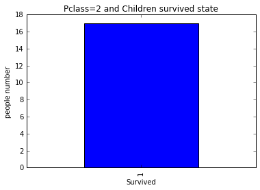

```python
fig = plt.figure()
fig.set(alpha=0.2)

df = titanic.Survived[titanic.Pclass==2][titanic.Children==1].value_counts()
df.plot(kind='bar', stacked=True)
plt.title(u"Pclass=2 and Children survived state")
plt.xlabel(u"Survived")
plt.ylabel(u"people number")
```

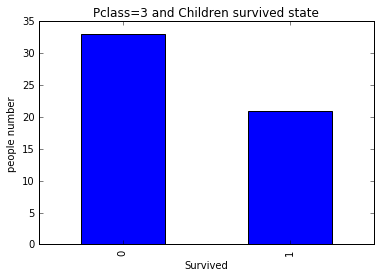

```python
fig = plt.figure()
fig.set(alpha=0.2)

df = titanic.Survived[titanic.Pclass==3][titanic.Children == 1].value_counts()
df.plot(kind='bar', stacked=True)
plt.title(u"Pclass=3 and Children survived state")
plt.xlabel(u"Survived")
plt.ylabel(u"people number")
```

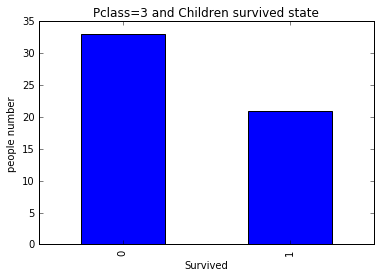

```python
fig = plt.figure()
fig.set(alpha=0.2)

df = titanic.Survived[titanic.Pclass==3][titanic.Children == 1].value_counts()
df.plot(kind='bar', stacked=True)
plt.title(u"Pclass=3 and Children survived state")
plt.xlabel(u"Survived")
plt.ylabel(u"people number")
```

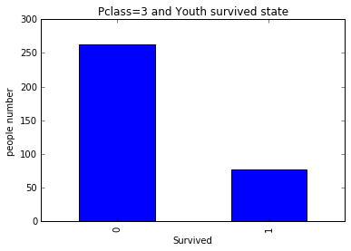

```python
fig = plt.figure()
fig.set(alpha=0.2)

df = titanic.Survived[titanic.Pclass==3][titanic.Youth == 1].value_counts()
df.plot(kind='bar', stacked=True)
plt.title(u"Pclass=3 and Youth survived state")
plt.xlabel(u"Survived")
plt.ylabel(u"people number")
```

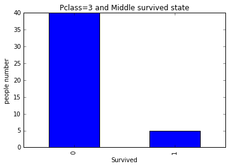

```python
fig = plt.figure()
fig.set(alpha=0.2)

df = titanic.Survived[titanic.Pclass==3][titanic.Middle == 1].value_counts()
df.plot(kind='bar', stacked=True)
plt.title(u"Pclass=3 and Middle survived state")
plt.xlabel(u"Survived")
plt.ylabel(u"people number")
```

图示结果：能够看到，同样对于儿童，Pcalss为1时，获救比例为75%，而Pclass为3时，该比例降低至不足50%，也更加证明了Pclass在获救中所占据的作用是巨大的，而对于相同的Pclass（此处取3），则依然是儿童的获救概率更大，也说明了小孩优先的基本情况；

#### Pclass+Embarked

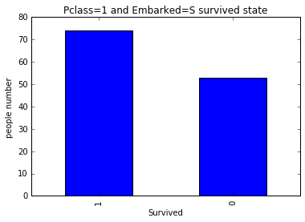

```python
fig = plt.figure()
fig.set(alpha=0.2)

df = titanic.Survived[titanic.Pclass==1][titanic.Embarked=='S'].value_counts()
df.plot(kind='bar', stacked=True)
plt.title(u"Pclass=1 and Embarked=S survived state")
plt.xlabel(u"Survived")
plt.ylabel(u"people number")
```

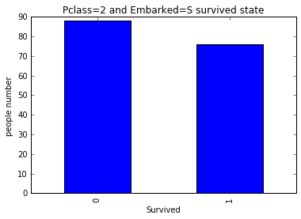

```python
fig = plt.figure()
fig.set(alpha=0.2)

df = titanic.Survived[titanic.Pclass==2][titanic.Embarked=='S'].value_counts()
df.plot(kind='bar', stacked=True)
plt.title(u"Pclass=2 and Embarked=S survived state")
plt.xlabel(u"Survived")
plt.ylabel(u"people number")
```

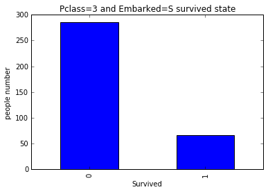

```python
fig = plt.figure()
fig.set(alpha=0.2)

df = titanic.Survived[titanic.Pclass==3][titanic.Embarked=='S'].value_counts()
df.plot(kind='bar', stacked=True)
plt.title(u"Pclass=3 and Embarked=S survived state")
plt.xlabel(u"Survived")
plt.ylabel(u"people number")
```

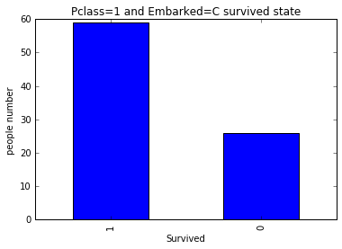

```python
fig = plt.figure()
fig.set(alpha=0.2)

df = titanic.Survived[titanic.Pclass==1][titanic.Embarked=='C'].value_counts()
df.plot(kind='bar', stacked=True)
plt.title(u"Pclass=1 and Embarked=C survived state")
plt.xlabel(u"Survived")
plt.ylabel(u"people number")
```

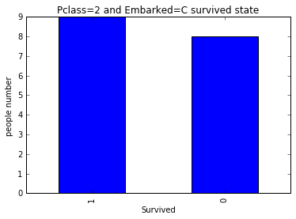

```python
fig = plt.figure()
fig.set(alpha=0.2)

df = titanic.Survived[titanic.Pclass==2][titanic.Embarked=='C'].value_counts()
df.plot(kind='bar', stacked=True)
plt.title(u"Pclass=2 and Embarked=C survived state")
plt.xlabel(u"Survived")
plt.ylabel(u"people number")
```

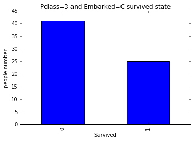

```python
fig = plt.figure()
fig.set(alpha=0.2)

df = titanic.Survived[titanic.Pclass==3][titanic.Embarked=='C'].value_counts()
df.plot(kind='bar', stacked=True)
plt.title(u"Pclass=3 and Embarked=C survived state")
plt.xlabel(u"Survived")
plt.ylabel(u"people number")
```

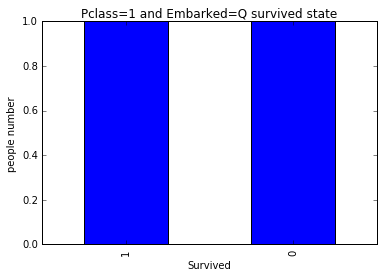

```python
fig = plt.figure()
fig.set(alpha=0.2)

df = titanic.Survived[titanic.Pclass==1][titanic.Embarked=='Q'].value_counts()
df.plot(kind='bar', stacked=True)
plt.title(u"Pclass=1 and Embarked=Q survived state")
plt.xlabel(u"Survived")
plt.ylabel(u"people number")
```

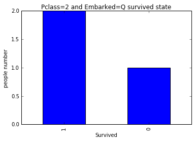

```python
fig = plt.figure()
fig.set(alpha=0.2)

df = titanic.Survived[titanic.Pclass==2][titanic.Embarked=='Q'].value_counts()
df.plot(kind='bar', stacked=True)
plt.title(u"Pclass=2 and Embarked=Q survived state")
plt.xlabel(u"Survived")
plt.ylabel(u"people number")
```

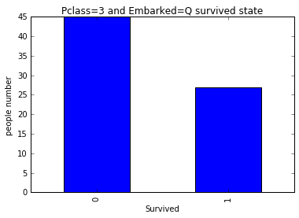

```python
fig = plt.figure()
fig.set(alpha=0.2)

df = titanic.Survived[titanic.Pclass==3][titanic.Embarked=='Q'].value_counts()
df.plot(kind='bar', stacked=True)
plt.title(u"Pclass=3 and Embarked=Q survived state")
plt.xlabel(u"Survived")
plt.ylabel(u"people number")
```

图示结果：看不出有明显的互相加成的情况，但是可以看到Q港口的Pclass为1的人数非常少，只有2个，也从侧面证明了之所以港口不同，获救比例相差很大，很可能就是由于各个港口的经济情况，导致个别港口的乘客更多为Pclass为1或者2的，而个别港口主要是Pclass为3的乘客导致的，根本原因不在于港口；

## 三变量

### Sex=female+Pclass=1+AgeStep=Children/Juvenile/Youth

[figure not shown]

```python
fig = plt.figure()
fig.set(alpha=0.2)

df = titanic.Survived[titanic.Sex=='female'][titanic.Pclass==1][titanic.Children==1].value_counts()
df.plot(kind='bar', stacked=True)
plt.title(u"male and Pclass=1 and Children=1 survived state")
plt.xlabel(u"Survived")
plt.ylabel(u"people number")
```

[figure not shown]

```python
fig = plt.figure()
fig.set(alpha=0.2)

df = titanic.Survived[titanic.Sex=='female'][titanic.Pclass==1][titanic.Juvenile==1].value_counts()
df.plot(kind='bar', stacked=True)
plt.title(u"male and Pclass=1 and Children=1 survived state")
plt.xlabel(u"Survived")
plt.ylabel(u"people number")
```

```
1    52
0     1
Name: Survived, dtype: int64
```

[figure not shown]

```python
fig = plt.figure()
fig.set(alpha=0.2)

df = titanic.Survived[titanic.Sex=='female'][titanic.Pclass==1][titanic.Youth==1].value_counts()
print df.head(2)
df.plot(kind='bar', stacked=True)
plt.title(u"male and Pclass=1 and Children=1 survived state")
plt.xlabel(u"Survived")
plt.ylabel(u"people number")
```

```
1    91
0     3
Name: Survived, dtype: int64
```

[figure not shown]

```python
fig = plt.figure()
fig.set(alpha=0.2)

df = titanic.Survived[titanic.Sex=='female'][titanic.Pclass==1].value_counts()
print df.head(2)
df.plot(kind='bar', stacked=True)
plt.title(u"male and Pclass=1 and Children=1 survived state")
plt.xlabel(u"Survived")
plt.ylabel(u"people number")
```

#### 三变量分析结论

首先根据之前的分析，Sex=‘female’，Pclass=1，AgeStep比较小时几率最大，首先由于AgeStep为Children时，只有一个样本满足，暂时忽略，当AgeStep为Juvenile，满足条件的10人全部获救已经证明了这三个特征组合的威力，当AgeStep为Youth时，获救概率也高达98%，最后一种组合是Sex=‘female’+Pclass=1的组合，也就是没考虑年龄的情况我们发现获救概率为96.8%，略低与第三步的98%，这个说明了虽然儿童获救概率更大，但是中老年人在获救比例上是低于平均的；

## 分析结论

一步一步分析下来，由单变量分析出了对幸存率影响较高较明显的几个变量，通过双变量分析了变量之间是否存在互相增加对幸存率影响的情况，通过三变量分析确定了现阶段认为最合适组合的三个特征以及对应的取值；

## 局限

对于Age字段的用法目前看来由于官方定义与个人对一个人的判定有冲突，比如官方定义中18岁以内即认为是青少年，但是可能在个人的判定中不一定会特殊照顾18岁的乘客，所以此处的AgeStep的定义就存在问题，也就是说Age字段更难利用的好；

## 项目总结

1. 掌握了缺失值的处理，Age字段通过其他的相关字段以及完整数据来填充缺失字段；
2. 掌握了数值型数据的使用，Age字段通过儿童，少年，青少年，中年，老年的官方年龄定义进行划分分析；
3. pandas数据可视化；
4. 分析结果在两个层面上是可信的：社会层面-女性优先，儿童优先，客观层面-越高级的船舱安全系数越高；